# 1. Business Problem

### 4.5.3. Feature Importance

#### 4.5.3.1. Correctly Classified point

```python
# test_point_index = 10
clf = RandomForestClassifier(n_estimators=l_alpha, criterion='gini', max_depth=l_max_depth, random_state=42, n_jobs=-1)
clf.fit(train_x_onehotCoding, train_y)
sig_clf = CalibratedClassifierCV(clf, method="sigmoid")
sig_clf.fit(train_x_onehotCoding, train_y)

test_point_index = 1
no_feature = 100
predicted_cls = sig_clf.predict(test_x_onehotCoding[test_point_index])
print("Predicted Class :", predicted_cls[0])
print("Predicted Class Probabilities:", np.round(sig_clf.predict_proba(test_x_onehotCoding[test_point_index]),4))
print("Actual Class :", test_y[test_point_index])
indices = np.argsort(-clf.feature_importances_)
print("-"*50)
get_impfeature_names(indices[:no_feature], test_df['TEXT'].iloc[test_point_index],test_df['Gene'].iloc[test_point_index],test_df['Variation'].iloc[test_point_index], no_feature)
```

```
Predicted Class : 1
Predicted Class Probabilities: [[0.4961 0.0669 0.0166 0.2447 0.0444 0.0436 0.0762 0.0052 0.0062]]
Actual Class : 1
--------------------------------------------------
18 Text feature [015] present in test data point [True]
30 Text feature [13] present in test data point [True]
40 Text feature [197] present in test data point [True]
Out of the top  100  features  3 are present in query point
```

```python
test_point_index = 100
no_feature = 100
predicted_cls = sig_clf.predict(test_x_onehotCoding[test_point_index])
print("Predicted Class :", predicted_cls[0])
print("Predicted Class Probabilities:", np.round(sig_clf.predict_proba(test_x_onehotCoding[test_point_index]),4))
print("Actuall Class :", test_y[test_point_index])
indices = np.argsort(-clf.feature_importances_)
print("-"*50)
get_impfeature_names(indices[:no_feature], test_df['TEXT'].iloc[test_point_index],test_df['Gene'].iloc[test_point_index],test_df['Variation'].iloc[test_point_index], no_feature)
```

```
Predicted Class : 7
Predicted Class Probabilities: [[0.0827 0.186  0.0161 0.0905 0.0426 0.0417 0.5282 0.0061 0.0062]]
Actuall Class : 7
--------------------------------------------------
30 Text feature [13] present in test data point [True]
Out of the top  100  features  1 are present in query point
```

### 4.5.3. Hyper paramter tuning (With Response Coding)

```python
# --------------------------------
# default parameters
# sklearn.ensemble.RandomForestClassifier(n_estimators=10, criterion=’gini’, max_depth=None, min_samples_split=2,
# min_samples_leaf=1, min_weight_fraction_leaf=0.0, max_features=’auto’, max_leaf_nodes=None, min_impurity_decrease=0.0,
# min_impurity_split=None, bootstrap=True, oob_score=False, n_jobs=1, random_state=None, verbose=0, warm_start=False,
# class_weight=None)

# Some of methods of RandomForestClassifier()
# fit(X, y, [sample_weight])	Fit the SVM model according to the given training data.
# predict(X)	Perform classification on samples in X.
# predict_proba (X)	Perform classification on samples in X.

# some of attributes of  RandomForestClassifier()
# feature_importances_ : array of shape = [n_features]
# The feature importances (the higher, the more important the feature).

# --------------------------------
# video link: https://www.appliedaicourse.com/course/applied-ai-course-online/lessons/random-forest-and-their-construction-2/
# --------------------------------


# find more about CalibratedClassifierCV here at http://scikit-learn.org/stable/modules/generated/sklearn.calibration.CalibratedClassifierCV.html
# ----------------------------
# default paramters
# sklearn.calibration.CalibratedClassifierCV(base_estimator=None, method=’sigmoid’, cv=3)
#
# some of the methods of CalibratedClassifierCV()
# fit(X, y[, sample_weight])	Fit the calibrated model
# get_params([deep])	Get parameters for this estimator.
# predict(X)	Predict the target of new samples.
# predict_proba(X)	Posterior probabilities of classification
#-------------------------------------
# video link:
#-------------------------------------

alpha = [10,50,100,200,500,1000, 2000]
max_depth = [2,3,5,10, 15, 25, 51]
cv_log_error_array = []
l_log_loss = 999
l_alpha = 0
l_max_depth = 0
for i in alpha:
    for j in max_depth:
        print("for n_estimators =", i,"and max depth = ", j)
        clf = RandomForestClassifier(n_estimators=i, criterion='gini', max_depth=j, random_state=42, n_jobs=-1)
        clf.fit(train_x_responseCoding, train_y)
        sig_clf = CalibratedClassifierCV(clf, method="sigmoid")
        sig_clf.fit(train_x_responseCoding, train_y)
        sig_clf_probs = sig_clf.predict_proba(cv_x_responseCoding)
        log_loss_val = log_loss(cv_y, sig_clf_probs, labels=clf.classes_, eps=1e-15)
        cv_log_error_array.append(log_loss_val)
        print("Log Loss :",log_loss_val)
        if l_log_loss > log_loss_val:
            l_log_loss = log_loss_val
            l_alpha = i
            l_max_depth = j
'''
fig, ax = plt.subplots()
features = np.dot(np.array(alpha)[:,None],np.array(max_depth)[None]).ravel()
ax.plot(features, cv_log_error_array,c='g')
for i, txt in enumerate(np.round(cv_log_error_array,3)):
    ax.annotate((alpha[int(i/4)],max_depth[int(i%4)],str(txt)), (features[i],cv_log_error_array[i]))
plt.grid()
plt.title("Cross Validation Error for each alpha")
plt.xlabel("Alpha i's")
plt.ylabel("Error measure")
plt.show()
'''

best_alpha = np.argmin(cv_log_error_array)
clf = RandomForestClassifier(n_estimators=l_alpha, criterion='gini', max_depth=l_max_depth, random_state=42, n_jobs=-1)
clf.fit(train_x_responseCoding, train_y)
sig_clf = CalibratedClassifierCV(clf, method="sigmoid")
sig_clf.fit(train_x_responseCoding, train_y)

predict_y = sig_clf.predict_proba(train_x_responseCoding)
train_log_loss = log_loss(y_train, predict_y, labels=clf.classes_, eps=1e-15)
print('For values of best alpha = ', l_alpha, "The train log loss is:", train_log_loss)
predict_y = sig_clf.predict_proba(cv_x_responseCoding)
cv_log_loss = log_loss(y_cv, predict_y, labels=clf.classes_, eps=1e-15)
print('For values of best alpha = ', l_alpha, "The cross validation log loss is:", cv_log_loss)
predict_y = sig_clf.predict_proba(test_x_responseCoding)
test_log_loss = log_loss(y_test, predict_y, labels=clf.classes_, eps=1e-15)
print('For values of best alpha = ', l_alpha, "The test log loss is:", test_log_loss)
```

```
for n_estimators = 10 and max depth =  2
Log Loss : 2.0236553850363266
for n_estimators = 10 and max depth =  3
Log Loss : 1.5807889980583667
for n_estimators = 10 and max depth =  5
Log Loss : 1.3319846120113743
for n_estimators = 10 and max depth =  10
Log Loss : 1.7021254652139617
for n_estimators = 10 and max depth =  15
Log Loss : 1.9725964624615715
for n_estimators = 10 and max depth =  25
Log Loss : 1.9392326546855967
for n_estimators = 10 and max depth =  51
Log Loss : 1.9392326546855967
for n_estimators = 50 and max depth =  2
Log Loss : 1.5629351284196198
for n_estimators = 50 and max depth =  3
Log Loss : 1.3355732634621753
for n_estimators = 50 and max depth =  5
Log Loss : 1.2379195931348093
for n_estimators = 50 and max depth =  10
Log Loss : 1.717936566012422
for n_estimators = 50 and max depth =  15
Log Loss : 1.8458281087393043
for n_estimators = 50 and max depth =  25
Log Loss : 1.8203450354310464
for n_estimators = 50 and max depth =  51
Log Loss : 1.8203450354310464
for n_estimators = 100 and max depth =  2
Log Loss : 1.431879591777632
for n_estimators = 100 and max depth =  3
Log Loss : 1.3385213469262618
for n_estimators = 100 and max depth =  5
Log Loss : 1.202232862553944
for n_estimators = 100 and max depth =  10
Log Loss : 1.6448489436423468
for n_estimators = 100 and max depth =  15
Log Loss : 1.8199276052576956
for n_estimators = 100 and max depth =  25
Log Loss : 1.8129700422835409
```

[output cut: 46 more lines]

```
for n_estimators = 2000 and max depth =  3
Log Loss : 1.4605379710154736
for n_estimators = 2000 and max depth =  5
Log Loss : 1.2965697338277975
for n_estimators = 2000 and max depth =  10
Log Loss : 1.7207268321949283
for n_estimators = 2000 and max depth =  15
Log Loss : 1.874579108496684
for n_estimators = 2000 and max depth =  25
Log Loss : 1.8771752982317493
for n_estimators = 2000 and max depth =  51
Log Loss : 1.8771752982317493
For values of best alpha =  100 The train log loss is: 0.06077609515841254
For values of best alpha =  100 The cross validation log loss is: 1.202232862553944
For values of best alpha =  100 The test log loss is: 1.2791294236128397
```

### 4.5.4. Testing model with best hyper parameters (Response Coding)

```
Log loss : 1.202232862553944
Number of mis-classified points : 0.4492481203007519
-------------------- Confusion matrix --------------------
```

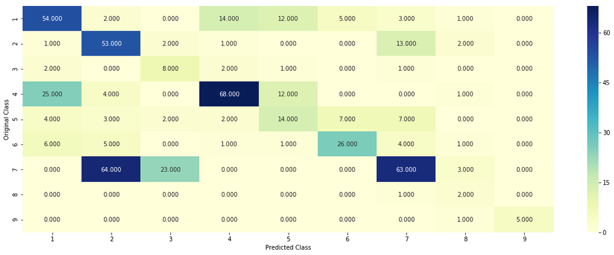

```
-------------------- Precision matrix (Columm Sum=1) --------------------
```

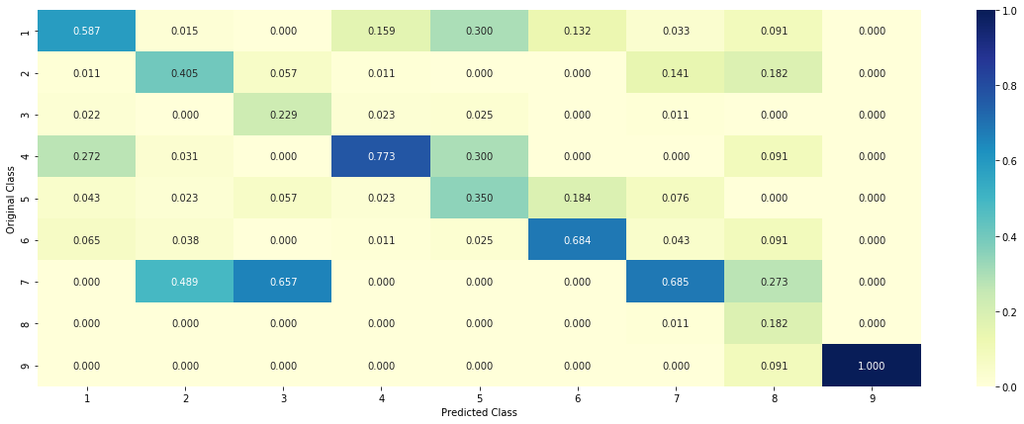

```
-------------------- Recall matrix (Row sum=1) --------------------
```

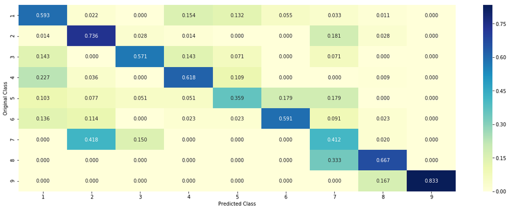

```python
# --------------------------------
# default parameters
# sklearn.ensemble.RandomForestClassifier(n_estimators=10, criterion=’gini’, max_depth=None, min_samples_split=2,
# min_samples_leaf=1, min_weight_fraction_leaf=0.0, max_features=’auto’, max_leaf_nodes=None, min_impurity_decrease=0.0,
# min_impurity_split=None, bootstrap=True, oob_score=False, n_jobs=1, random_state=None, verbose=0, warm_start=False,
# class_weight=None)

# Some of methods of RandomForestClassifier()
# fit(X, y, [sample_weight])	Fit the SVM model according to the given training data.
# predict(X)	Perform classification on samples in X.
# predict_proba (X)	Perform classification on samples in X.

# some of attributes of  RandomForestClassifier()
# feature_importances_ : array of shape = [n_features]
# The feature importances (the higher, the more important the feature).

# --------------------------------
# video link: https://www.appliedaicourse.com/course/applied-ai-course-online/lessons/random-forest-and-their-construction-2/
# --------------------------------

clf = RandomForestClassifier(max_depth=l_max_depth, n_estimators=l_alpha, criterion='gini', max_features='auto',random_state=42)
log_loss_val, misc_rate = predict_and_plot_confusion_matrix(train_x_responseCoding, train_y,cv_x_responseCoding,cv_y, clf)

result_report = result_report.append({"Vectorizer": "TF-IDF", "N-Gram": "(1,4)",
                                      "Model": "RandomForest (With Response-Encoding)",
                                      "TRAIN-Score": np.round(train_log_loss, 4),
                                      "CV-Score": np.round(cv_log_loss, 4),
                                      "TEST-Score": np.round(test_log_loss, 4),
                                      "Misclassification-Rate": '{}%'.format(np.round(misc_rate * 100, 2))
                                     }, ignore_index=True)
```

### 4.5.5. Feature Importance

#### 4.5.5.1. Correctly Classified point

```python
clf = RandomForestClassifier(n_estimators=l_alpha, criterion='gini', max_depth=l_max_depth, random_state=42, n_jobs=-1)
clf.fit(train_x_responseCoding, train_y)
sig_clf = CalibratedClassifierCV(clf, method="sigmoid")
sig_clf.fit(train_x_responseCoding, train_y)


test_point_index = 1
no_feature = 27
predicted_cls = sig_clf.predict(test_x_responseCoding[test_point_index].reshape(1,-1))
print("Predicted Class :", predicted_cls[0])
print("Predicted Class Probabilities:", np.round(sig_clf.predict_proba(test_x_responseCoding[test_point_index].reshape(1,-1)),4))
print("Actual Class :", test_y[test_point_index])
indices = np.argsort(-clf.feature_importances_)
print("-"*50)
for i in indices:
    if i<9:
        print("Gene is important feature")
    elif i<18:
        print("Variation is important feature")
    else:
        print("Text is important feature")
```

```
Predicted Class : 1
Predicted Class Probabilities: [[0.9813 0.0021 0.0014 0.0038 0.0014 0.0027 0.0019 0.0025 0.0027]]
Actual Class : 1
--------------------------------------------------
Variation is important feature
Variation is important feature
Variation is important feature
Variation is important feature
Gene is important feature
Variation is important feature
Text is important feature
Variation is important feature
Text is important feature
Text is important feature
Text is important feature
Gene is important feature
Text is important feature
Gene is important feature
Variation is important feature
Gene is important feature
Text is important feature
Gene is important feature
Variation is important feature
Gene is important feature
Text is important feature
Text is important feature
Text is important feature
Variation is important feature
Gene is important feature
Gene is important feature
Gene is important feature
```

#### 4.5.5.2. Incorrectly Classified point

```python
test_point_index = 100
predicted_cls = sig_clf.predict(test_x_responseCoding[test_point_index].reshape(1,-1))
print("Predicted Class :", predicted_cls[0])
print("Predicted Class Probabilities:", np.round(sig_clf.predict_proba(test_x_responseCoding[test_point_index].reshape(1,-1)),4))
print("Actual Class :", test_y[test_point_index])
indices = np.argsort(-clf.feature_importances_)
print("-"*50)
for i in indices:
    if i<9:
        print("Gene is important feature")
    elif i<18:
        print("Variation is important feature")
    else:
        print("Text is important feature")
```

```
Predicted Class : 2
Predicted Class Probabilities: [[0.0161 0.4509 0.0867 0.0194 0.0351 0.0389 0.3147 0.0237 0.0144]]
Actual Class : 7
--------------------------------------------------
Variation is important feature
Variation is important feature
Variation is important feature
Variation is important feature
Gene is important feature
Variation is important feature
Text is important feature
Variation is important feature
Text is important feature
Text is important feature
Text is important feature
Gene is important feature
Text is important feature
Gene is important feature
Variation is important feature
Gene is important feature
Text is important feature
Gene is important feature
Variation is important feature
Gene is important feature
Text is important feature
Text is important feature
Text is important feature
Variation is important feature
Gene is important feature
Gene is important feature
Gene is important feature
```

## 4.7 Stack the models

### 4.7.1 testing with hyper parameter tuning

```python
# read more about SGDClassifier() at http://scikit-learn.org/stable/modules/generated/sklearn.linear_model.SGDClassifier.html
# ------------------------------
# default parameters
# SGDClassifier(loss=’hinge’, penalty=’l2’, alpha=0.0001, l1_ratio=0.15, fit_intercept=True, max_iter=None, tol=None,
# shuffle=True, verbose=0, epsilon=0.1, n_jobs=1, random_state=None, learning_rate=’optimal’, eta0=0.0, power_t=0.5,
# class_weight=None, warm_start=False, average=False, n_iter=None)

# some of methods
# fit(X, y[, coef_init, intercept_init, …])	Fit linear model with Stochastic Gradient Descent.
# predict(X)	Predict class labels for samples in X.

#-------------------------------
# video link: https://www.appliedaicourse.com/course/applied-ai-course-online/lessons/geometric-intuition-1/
#------------------------------


# read more about support vector machines with linear kernals here http://scikit-learn.org/stable/modules/generated/sklearn.svm.SVC.html
# --------------------------------
# default parameters
# SVC(C=1.0, kernel=’rbf’, degree=3, gamma=’auto’, coef0=0.0, shrinking=True, probability=False, tol=0.001,
# cache_size=200, class_weight=None, verbose=False, max_iter=-1, decision_function_shape=’ovr’, random_state=None)

# Some of methods of SVM()
# fit(X, y, [sample_weight])	Fit the SVM model according to the given training data.
# predict(X)	Perform classification on samples in X.
# --------------------------------
# video link: https://www.appliedaicourse.com/course/applied-ai-course-online/lessons/mathematical-derivation-copy-8/
# --------------------------------


# read more about support vector machines with linear kernals here http://scikit-learn.org/stable/modules/generated/sklearn.ensemble.RandomForestClassifier.html
# --------------------------------
# default parameters
# sklearn.ensemble.RandomForestClassifier(n_estimators=10, criterion=’gini’, max_depth=None, min_samples_split=2,
# min_samples_leaf=1, min_weight_fraction_leaf=0.0, max_features=’auto’, max_leaf_nodes=None, min_impurity_decrease=0.0,
# min_impurity_split=None, bootstrap=True, oob_score=False, n_jobs=1, random_state=None, verbose=0, warm_start=False,
# class_weight=None)

# Some of methods of RandomForestClassifier()
# fit(X, y, [sample_weight])	Fit the SVM model according to the given training data.
# predict(X)	Perform classification on samples in X.
# predict_proba (X)	Perform classification on samples in X.

# some of attributes of  RandomForestClassifier()
# feature_importances_ : array of shape = [n_features]
# The feature importances (the higher, the more important the feature).

# --------------------------------
# video link: https://www.appliedaicourse.com/course/applied-ai-course-online/lessons/random-forest-and-their-construction-2/
# --------------------------------


clf1 = SGDClassifier(alpha=0.001, penalty='l2', loss='log', class_weight='balanced', random_state=0)
clf1.fit(train_x_onehotCoding, train_y)
sig_clf1 = CalibratedClassifierCV(clf1, method="sigmoid")

clf2 = SGDClassifier(alpha=1, penalty='l2', loss='hinge', class_weight='balanced', random_state=0)
clf2.fit(train_x_onehotCoding, train_y)
sig_clf2 = CalibratedClassifierCV(clf2, method="sigmoid")


clf3 = MultinomialNB(alpha=0.001)
clf3.fit(train_x_onehotCoding, train_y)
sig_clf3 = CalibratedClassifierCV(clf3, method="sigmoid")

sig_clf1.fit(train_x_onehotCoding, train_y)
print("Logistic Regression :  Log Loss: %0.2f" % (log_loss(cv_y, sig_clf1.predict_proba(cv_x_onehotCoding))))
sig_clf2.fit(train_x_onehotCoding, train_y)
print("Support vector machines : Log Loss: %0.2f" % (log_loss(cv_y, sig_clf2.predict_proba(cv_x_onehotCoding))))
sig_clf3.fit(train_x_onehotCoding, train_y)
print("Naive Bayes : Log Loss: %0.2f" % (log_loss(cv_y, sig_clf3.predict_proba(cv_x_onehotCoding))))
print("-"*50)
alpha = sorted([0.0001,0.001,0.01,0.1,1,10]  + [2**i for i in range(-10, -1)] + [2**i for i in range(1, 5)])
best_alpha = 999
best_alpha_val = 999
for i in alpha:
    lr = LogisticRegression(C=i)
    sclf = StackingClassifier(classifiers=[sig_clf1, sig_clf2, sig_clf3], meta_classifier=lr, use_probas=True)
    sclf.fit(train_x_onehotCoding, train_y)
    print("Stacking Classifer : for the value of alpha: %f Log Loss: %0.3f" % (i, log_loss(cv_y, sclf.predict_proba(cv_x_onehotCoding))))
    log_error =log_loss(cv_y, sclf.predict_proba(cv_x_onehotCoding))
    if best_alpha_val > log_error:
        best_alpha_val = log_error
        best_alpha = i
```

```
Logistic Regression :  Log Loss: 0.98
Support vector machines : Log Loss: 1.37
Naive Bayes : Log Loss: 1.20
--------------------------------------------------
Stacking Classifer : for the value of alpha: 0.000100 Log Loss: 2.178
Stacking Classifer : for the value of alpha: 0.000977 Log Loss: 2.037
Stacking Classifer : for the value of alpha: 0.001000 Log Loss: 2.034
Stacking Classifer : for the value of alpha: 0.001953 Log Loss: 1.923
Stacking Classifer : for the value of alpha: 0.003906 Log Loss: 1.765
Stacking Classifer : for the value of alpha: 0.007812 Log Loss: 1.578
Stacking Classifer : for the value of alpha: 0.010000 Log Loss: 1.510
Stacking Classifer : for the value of alpha: 0.015625 Log Loss: 1.397
Stacking Classifer : for the value of alpha: 0.031250 Log Loss: 1.257
Stacking Classifer : for the value of alpha: 0.062500 Log Loss: 1.173
Stacking Classifer : for the value of alpha: 0.100000 Log Loss: 1.146
Stacking Classifer : for the value of alpha: 0.125000 Log Loss: 1.141
Stacking Classifer : for the value of alpha: 0.250000 Log Loss: 1.153
Stacking Classifer : for the value of alpha: 1.000000 Log Loss: 1.289
Stacking Classifer : for the value of alpha: 2.000000 Log Loss: 1.393
Stacking Classifer : for the value of alpha: 4.000000 Log Loss: 1.510
Stacking Classifer : for the value of alpha: 8.000000 Log Loss: 1.633
Stacking Classifer : for the value of alpha: 10.000000 Log Loss: 1.673
Stacking Classifer : for the value of alpha: 16.000000 Log Loss: 1.760
```

### 4.7.2 testing the model with the best hyper parameters

```
Log loss (train) on the stacking classifier : 0.5724591020092523
Log loss (CV) on the stacking classifier : 1.1405524074096804
Log loss (test) on the stacking classifier : 1.166001181456692
Number of missclassified point : 0.3924812030075188
-------------------- Confusion matrix --------------------
```

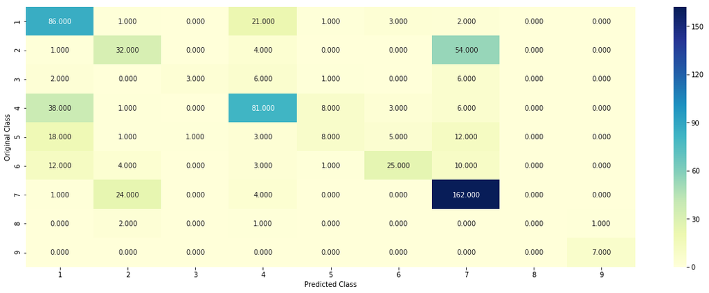

```
-------------------- Precision matrix (Columm Sum=1) --------------------
```

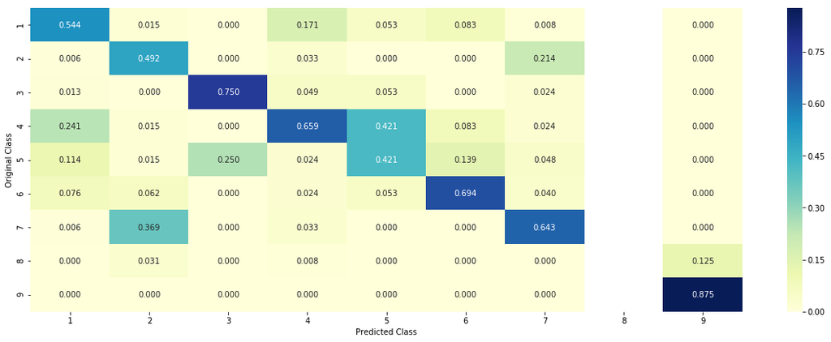

```
-------------------- Recall matrix (Row sum=1) --------------------
```

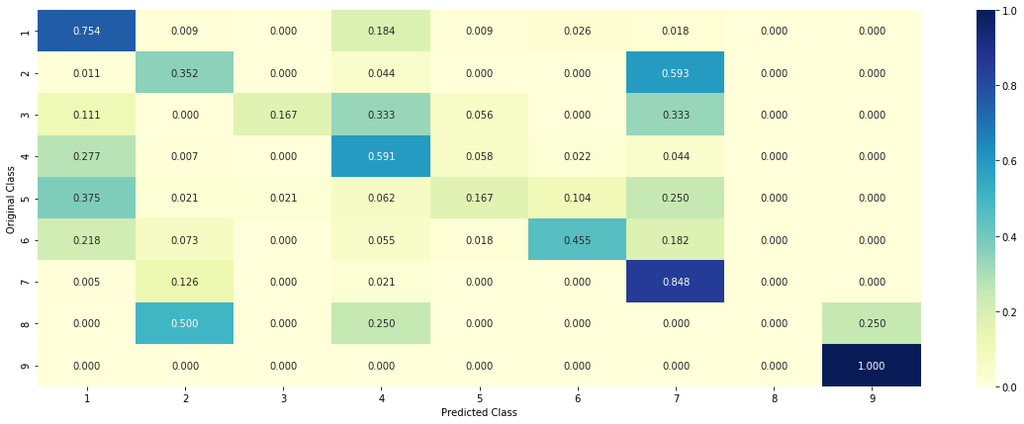

```python
lr = LogisticRegression(C=best_alpha)
sclf = StackingClassifier(classifiers=[sig_clf1, sig_clf2, sig_clf3], meta_classifier=lr, use_probas=True)
sclf.fit(train_x_onehotCoding, train_y)

log_error_train = log_loss(train_y, sclf.predict_proba(train_x_onehotCoding))
print("Log loss (train) on the stacking classifier :",log_error_train)

log_error_cv = log_loss(cv_y, sclf.predict_proba(cv_x_onehotCoding))
print("Log loss (CV) on the stacking classifier :",log_error_cv)

log_error_test = log_loss(test_y, sclf.predict_proba(test_x_onehotCoding))
print("Log loss (test) on the stacking classifier :",log_error_test)

misc_rate = np.count_nonzero((sclf.predict(test_x_onehotCoding)- test_y))/test_y.shape[0]
print("Number of missclassified point :", misc_rate)
plot_confusion_matrix(test_y=test_y, predict_y=sclf.predict(test_x_onehotCoding))

result_report = result_report.append({"Vectorizer": "TF-IDF", "N-Gram": "(1,4)",
                                      "Model": "Stacking [LogisticRegression, SVM, NaiveBayes ===> LogisticRegression]",
                                      "TRAIN-Score": np.round(log_error_train, 4),
                                      "CV-Score": np.round(log_error_cv, 4),
                                      "TEST-Score": np.round(log_error_test, 4),
                                      "Misclassification-Rate": '{}%'.format(np.round(misc_rate * 100, 2))
                                     }, ignore_index=True)
```

### 4.7.3 Maximum Voting classifier

```
Log loss (train) on the VotingClassifier : 0.8106926083162947
Log loss (CV) on the VotingClassifier : 1.1141393164683024
Log loss (test) on the VotingClassifier : 1.157441526662839
Number of missclassified point : 0.3849624060150376
-------------------- Confusion matrix --------------------
```

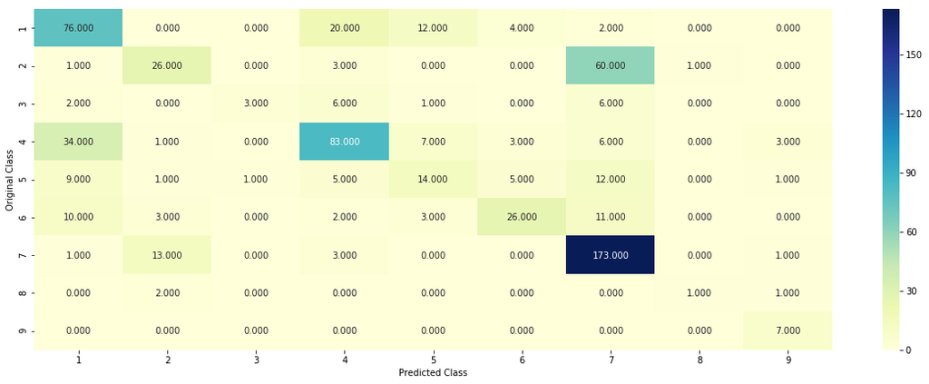

```
-------------------- Precision matrix (Columm Sum=1) --------------------
```

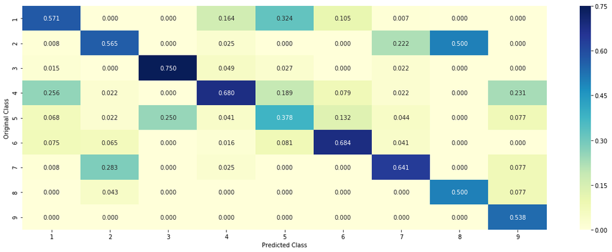

```
-------------------- Recall matrix (Row sum=1) --------------------
```

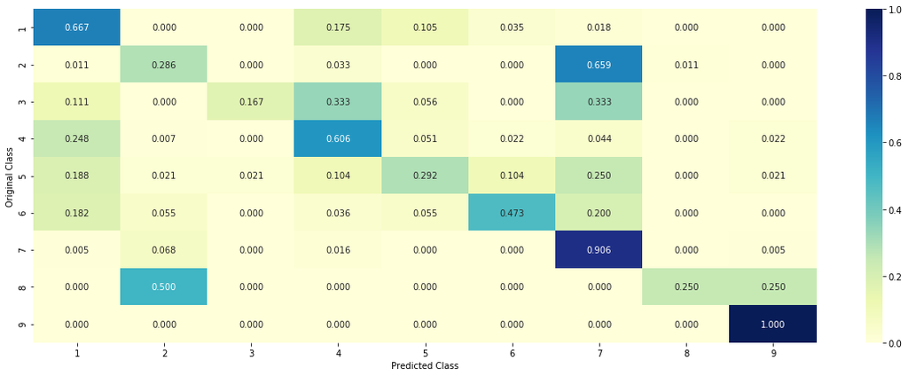

```python
#Refer:http://scikit-learn.org/stable/modules/generated/sklearn.ensemble.VotingClassifier.html
from sklearn.ensemble import VotingClassifier
vclf = VotingClassifier(estimators=[('lr', sig_clf1), ('svc', sig_clf2), ('rf', sig_clf3)], voting='soft')
vclf.fit(train_x_onehotCoding, train_y)
log_error_train = log_loss(train_y, vclf.predict_proba(train_x_onehotCoding))
print("Log loss (train) on the VotingClassifier :", log_error_train)
log_error_cv = log_loss(cv_y, vclf.predict_proba(cv_x_onehotCoding))
print("Log loss (CV) on the VotingClassifier :", log_error_cv)
log_error_test = log_loss(test_y, vclf.predict_proba(test_x_onehotCoding))
print("Log loss (test) on the VotingClassifier :", log_error_test)
misc_rate = np.count_nonzero((vclf.predict(test_x_onehotCoding)- test_y))/test_y.shape[0]
print("Number of missclassified point :", misc_rate)
plot_confusion_matrix(test_y=test_y, predict_y=vclf.predict(test_x_onehotCoding))

result_report = result_report.append({"Vectorizer": "TF-IDF", "N-Gram": "(1,4)",
                                      "Model": "Maximum Voting Classifier [LogisticRegression, SVM, RandomForest]",
                                      "TRAIN-Score": np.round(log_error_train, 4),
                                      "CV-Score": np.round(log_error_cv, 4),
                                      "TEST-Score": np.round(log_error_test, 4),
                                      "Misclassification-Rate": '{}%'.format(np.round(misc_rate * 100, 2))
                                     }, ignore_index=True)
```

# 5. Conclusions

```python
pd.options.display.max_colwidth = 100
result_report
```

[output not shown]

```python
print("Printing the minimum test score for model.. ")
result_report[result_report['TEST-Score']== result_report['TEST-Score'].min()]
```

```
Printing the minimum test score for model..
```

|  | Vectorizer | N-Gram | Model | TRAIN-Score | CV-Score | TEST-Score | Misclassification-Rate |
| --- | --- | --- | --- | --- | --- | --- | --- |
| 2 | TF-IDF | (1,4) | Logistic-Regression (With Class Balanced) | 0.4807 | 0.9429 | 0.9917 | 34.59% |

**Summary**

#### This is a multi-class classification problem where the output variable is having values 1-9.

Dataset size ~ 3k

Dataset consist of 2 files - *variants and text.*

*Variant file contains features like ID, Variation, Gene*

*Text file contains features ID and text*

Basically, we had to combine both files on the ID feature. The Variation and Gene feature are the categorical features whereas the Text feature is a text feature which we needed to vectorize. We tried both *Onehot encoding as well as response coding* with the categorical features.

So we used *TF-IDF (Term Frequency and Inverse Document Frequency) vectorizer* with some minor feature engineering by taking a *4 gram range and selecting the top 2k features*.

A variety of different models were tried including *Naive Bayes, Support Vector Machine, K-Nearest Neighbors, Logistic Regression, RandomForest.*

Since Logistic Regression was performing well, We tried with *BoW(Bag of Words) - both unigram and bi-gram vectorizer* as well to dig in more.

### As we can see the report above, Logistic Regression with Class balancing works well with CV logloss score to be of 0.94 and Test logloss score 0.99. Also the misclassification rate comes out to be only 34%.